# Hand Gesture Recognition

This project will be completed in two parts.

In Part A I will:

1. Generate and preprocess my own data
2. Load and split data for training, validation and testing

In Part B I will: 3. Train a Convolutional Neural Network to make classifications on different hand gestures 4. Apply transfer learning to improve my model

# Part A. Data Collection

### American Sign Language

American Sign Language (ASL) is a complete, complex language that employs signs made by moving the hands combined with facial expressions and postures of the body. It is the primary language of many North Americans who are deaf and is one of several communication options used by people who are deaf or hard-of-hearing.

The hand gestures representing English alphabet are shown below. This assignment focuses on classifying a subset of these hand gesture images using convolutional neural networks. Specifically, given an image of a hand showing one of the letters A-I, we want to detect which letter is being represented.

[figure not shown]

### Generating Data

I will collect and clean three images each of Americal Sign Language gestures for letters A - I (total of 27 images) Steps involved in data collection

1. Get familiar with American Sign Language gestures for letters from A - I (9 letters).
2. Take three pictures at slightly different orientation for each letter gesture using ymy mobile phone.
- Ensure adequate lighting while I am capturing the images.
- Use a white wall as my background.
- Use my right hand to create gestures (for consistency).
- Keep my right hand fairly apart from my body and any other obstructions.
- Avoid having shadows on parts of my hand.
3. Transfer the images to my laptop for cleaning.

### Cleaning Data

To simplify the machine learning the task, I will standardize the training images. I will make sure that all my images are of the same size (224 x 224 pixels RGB), and have the hand in the center of the cropped regions.

### Accepted Images

Images will be accepted based on the criteria below

1. The final image should be size 224x224 pixels (RGB).
2. The file format should be a .jpg file.
3. The hand should be approximately centered on the frame.
4. The hand should not be obscured or cut off.
5. The photos follows the ASL gestures posted earlier.
6. The photos were not edited in any other way (e.g. no electronic removal of shadows or background).

[figure not shown]

# Part B. Building a CNN

For this project, I will be writing a convolutional neural network from scratch.

## Part 1. Data Loading and Splitting

Download the anonymized data provided on Quercus. Split the data into training, validation, and test sets.

```python
import numpy as np
import matplotlib.pyplot as plt
import torch
from torchvision import datasets, transforms
from google.colab import drive
import torch.nn as nn
import torch.nn.functional as F
import torch.optim as optim #for gradient descent
from torch.utils.data import DataLoader, Dataset
```

```python
drive.mount('/content/gdrive')
data_path = '/content/gdrive/My Drive/Colab Notebooks/MIE1517/A2/Lab_3b_Gesture_Dataset'
transform = transforms.Compose(
    [transforms.ToTensor(),
     transforms.Normalize(mean=[0.5, 0.5, 0.5], std=[0.5, 0.5, 0.5])])  #make backpropagation stable

#randomly sample student
np.random.seed(1)
student_number = list(range(1,103)) # each letter has 102 students at most
sampled_student = np.random.choice(student_number, (2, 15), replace=False) # 15 students each for validaiton and testing set

def is_train_data(filename):
  file_name = filename.split('/')[-1].split('_') #extract student number
  #check if it is validation data
  for student in sampled_student[0]:
    if student == int(file_name[0]):
      return False
  #check if it is test data
  for student in sampled_student[1]:
    if student == int(file_name[0]):
      return False
  return True

def is_val_data(filename):
  file_name = filename.split('/')[-1].split('_') #extract student number
  for student in sampled_student[0]:
    if student == int(file_name[0]):
      return True
  return False

def is_test_data(filename):
  file_name = filename.split('/')[-1].split('_') #extract student number
  for student in sampled_student[1]:
    if student == int(file_name[0]):
      return True
  return False

train_data = datasets.ImageFolder(data_path, transform=transform, loader=plt.imread, is_valid_file=is_train_data)
val_data = datasets.ImageFolder(data_path, transform=transform, loader=plt.imread, is_valid_file=is_val_data)
test_data = datasets.ImageFolder(data_path, transform=transform, loader=plt.imread, is_valid_file=is_test_data)
```

```python
full_data = len(train_data) + len(val_data)+len(test_data)
print('Training data has', len(train_data),'images, is', len(train_data)/full_data*100, '% of original dataset')
print('Validation data has', len(val_data),'images, is', len(val_data)/full_data*100, '% of original dataset')
print('Test data has', len(test_data),'images, is', len(test_data)/full_data*100, '% of original dataset')
```

```
Training data has 1661 images, is 68.32579185520362 % of original dataset
Validation data has 369 images, is 15.178938708350472 % of original dataset
Test data has 401 images, is 16.495269436445906 % of original dataset
```

As demonstrated on the code above, my spliting strategy is based on students. Since every student can take 3 pictures for each letter, pictures taken by the same student are somewhat similar, hence it is important to group them together and split them in the same set to avoid data leak. Otherwise, our test set may contain pictures similar to those in training set, which makes our test set not totally "unseen" and the true perfomance of our model is hard to measure. Since the format of each image is "student number_letter_image number", I randomly sampled(without replacement) 15 student numbers for validation set and another 15 for test set. Then I matched these student numbers with student number in filename to get 15 students for validation set and 15 students for test set. I chose 15 for each validation and test set because there are 102 students in total and I think 70:15:15 is a reasonable split for training, validation and test. Result shows that there are 1661 images for training data(68.33%), 369 images for validation data(15.18%), 401 images for test data (16.50%). The validation set and test set is not exactly 15*27=405 images for each. This is because not every student take 3 pictures for each letter, some students took only 2 pictures and some students didn't take pictures for a letter. However, the percentages look as desired, so my spliting strategy is good.

## Part 2. Model Building and Sanity Checking

### Part (i) Convolutional Network

I built a convolutional neural network model that takes the (224x224 RGB) image as input, and predicts the gesture letter.

```python
class CNN(nn.Module):
      def __init__(self):
          super(CNN, self).__init__()
          self.name = "cnn"
          self.conv1 = nn.Conv2d(3, 5, 5) #in_channels, out_chanels, kernel_size
          self.pool = nn.MaxPool2d(2, 2) #kernel_size, stride
          self.conv2 = nn.Conv2d(5, 10, 5) #in_channels, out_chanels, kernel_size
          self.fc1 = nn.Linear(10*53*53, 32)
          self.fc2 = nn.Linear(32, 9) #predict A-I

      def forward(self, x):
          x = self.pool(F.relu(self.conv1(x)))
          x = self.pool(F.relu(self.conv2(x)))
          x = x.view(-1, 10*53*53)
          x = F.relu(self.fc1(x))
          x = self.fc2(x)
          return x
```

I chose a Convolutional Neural Network architecture with 2 convolutional layers, 2 pooling layers, and 2 fully-connected layers. I chose this because convolutional layers help detect and learn specific spatial features, max pooling leayers can consolidate information and fully-connected layers help classify to labels. I used ReLU as activation function after convolutional layers to introduce nonlinearity in model. I chose kernel size = 5 for convolutional layers and kernel size = 2, stride = 2 for max pooling layers. The number of input channels for first convolutional layer is 3 and output is 5. For second convolutional layer, number of input channels is 5(coming from previous layer) and number of output channels is 10. For number of input channels in first fully-connected layer, I used image size(224) and calculated its shape after each convolutional and pooling layer.

### Part (ii) Training Code

Write code that trains my neural network given some training data.

```python
def get_accuracy(model, train=False, batch_size=64):
    if train:
        data = train_data
    else:
        data = val_data

    correct = 0
    total = 0
    for imgs, labels in torch.utils.data.DataLoader(data, batch_size):


        #############################################
        #To Enable GPU Usage
        if use_cuda and torch.cuda.is_available():
          imgs = imgs.cuda()
          labels = labels.cuda()
        #############################################


        output = model(imgs)

        #select index with maximum prediction score
        pred = output.max(1, keepdim=True)[1]
        correct += pred.eq(labels.view_as(pred)).sum().item()
        total += imgs.shape[0]
    return correct / total
```

```python
def get_model_name(name, batch_size, learning_rate, epoch):
    path = "model_{0}_bs{1}_lr{2}_epoch{3}".format(name, batch_size, learning_rate, epoch)
    return path
```

```python
def train(model, data, batch_size=64, num_epochs=80, learning_rate=0.001):
    train_loader = torch.utils.data.DataLoader(data, batch_size=batch_size)
    print(train_loader)
    criterion = nn.CrossEntropyLoss()
    optimizer = optim.SGD(model.parameters(), lr=learning_rate, momentum=0.95)

    iters, losses, train_acc, val_acc = [], [], [], []

    # training
    n = 0 # the number of iterations

    for epoch in range(num_epochs):
        for imgs, labels in iter(train_loader):


            #############################################
            #To Enable GPU Usage
            if use_cuda and torch.cuda.is_available():
              imgs = imgs.cuda()
              labels = labels.cuda()
            #############################################


            out = model(imgs)             # forward pass
            loss = criterion(out, labels) # compute the total loss
            loss.backward()               # backward pass (compute parameter updates)
            optimizer.step()              # make the updates for each parameter
            optimizer.zero_grad()         # a clean up step for PyTorch

            # save the current training information
            iters.append(n)
            losses.append(float(loss)/batch_size)             # compute *average* loss
            n += 1

        # save accuracy
        train_acc.append(get_accuracy(model, train=True, batch_size = batch_size)) # compute training accuracy
        val_acc.append(get_accuracy(model, train=False, batch_size = batch_size))  # compute validation accuracy

        # save model(checkpoint)
        model_path = get_model_name(model.name, batch_size, learning_rate, epoch)
        torch.save(model.state_dict(), model_path)

  # plotting
    plt.title("Training Curve")
    plt.plot(iters, losses, label="Train")
    plt.xlabel("Iterations")
    plt.ylabel("Loss")
    plt.show()

    plt.title("Training Curve")
    plt.plot(range(1, num_epochs+1), train_acc, label="Train")
    plt.plot(range(1, num_epochs+1), val_acc, label="Validation")
    plt.xlabel("Epochs")
    plt.ylabel("Training Accuracy")
    plt.legend(loc='best')
    plt.show()

    print("Final Training Accuracy: {}".format(train_acc[-1]))
    print("Final Validation Accuracy: {}".format(val_acc[-1]))
```

For loss function, I chose Cross-Entropy Loss because it is suitable for multi-class classification. For optimizer, I used Stochastic Gradient Descent(SGD) because it allows me to do a global search for an optimum, which often results in a better set of weights for model.

### Part (iii) “Overfit” to a Small Dataset

One way to sanity check our neural network model and training code is to check whether the model is capable of “overfitting” or “memorizing” a small dataset. A properly constructed CNN with correct training code should be able to memorize the answers to a small number of images quickly.

I construct a small dataset (e.g. just the images that I have collected) and show that my model and training code is capable of memorizing the labels of this small data set.

```python
data_small = datasets.ImageFolder('/content/gdrive/My Drive/Colab Notebooks/MIE1517/A2/Lee_1004840381', transform=transform, loader=plt.imread)
```

```python
def get_accuracy_small(model):
    data = data_small
    correct = 0
    total = 0
    for imgs, labels in torch.utils.data.DataLoader(data, batch_size=27):


        #############################################
        #To Enable GPU Usage
        if use_cuda and torch.cuda.is_available():
          imgs = imgs.cuda()
          labels = labels.cuda()
        #############################################


        output = model(imgs)

        #select index with maximum prediction score
        pred = output.max(1, keepdim=True)[1]
        correct += pred.eq(labels.view_as(pred)).sum().item()
        total += imgs.shape[0]
    return correct / total
```

```python
def train_small(model, data, batch_size=27, num_epochs=30, learning_rate=0.001):
    train_loader = torch.utils.data.DataLoader(data, batch_size=batch_size)
    print(train_loader)
    criterion = nn.CrossEntropyLoss()
    optimizer = optim.SGD(model.parameters(), lr=learning_rate, momentum=0.9)

    iters, losses, train_acc, val_acc = [], [], [], []

    # training
    n = 0 # the number of iterations

    for epoch in range(num_epochs):
        for imgs, labels in iter(train_loader):


            #############################################
            #To Enable GPU Usage
            if use_cuda and torch.cuda.is_available():
              imgs = imgs.cuda()
              labels = labels.cuda()
            #############################################

            out = model(imgs)             # forward pass
            loss = criterion(out, labels) # compute the total loss
            loss.backward()               # backward pass (compute parameter updates)
            optimizer.step()              # make the updates for each parameter
            optimizer.zero_grad()         # a clean up step for PyTorch

            # save the current training information
            iters.append(n)
            losses.append(float(loss)/batch_size)             # compute *average* loss
            train_acc.append(get_accuracy_small(model)) # compute training accuracy
            n += 1

        # save model(checkpoint)
        model_path = get_model_name(model.name, batch_size, learning_rate, epoch)
        torch.save(model.state_dict(), model_path)

        print("Epoch:", epoch, "; Training accuracy:", train_acc[-1])

  # plotting
    plt.title("Training Curve")
    plt.plot(iters, losses, label="Train")
    plt.xlabel("Iterations")
    plt.ylabel("Loss")
    plt.show()

    plt.title("Training Curve")
    plt.plot(iters, train_acc, label="Train")
    plt.xlabel("Iterations")
    plt.ylabel("Training Accuracy")
    plt.legend(loc='best')
    plt.show()

    print("Final Training Accuracy: {}".format(train_acc[-1]))
```

```
CUDA is available!  Training on GPU ...
<torch.utils.data.dataloader.DataLoader object at 0x7bf850219780>
Epoch: 0 ; Training accuracy: 0.1111111111111111
Epoch: 1 ; Training accuracy: 0.1111111111111111
Epoch: 2 ; Training accuracy: 0.1111111111111111
Epoch: 3 ; Training accuracy: 0.1111111111111111
Epoch: 4 ; Training accuracy: 0.1111111111111111
Epoch: 5 ; Training accuracy: 0.1111111111111111
Epoch: 6 ; Training accuracy: 0.1111111111111111
Epoch: 7 ; Training accuracy: 0.1111111111111111
Epoch: 8 ; Training accuracy: 0.1111111111111111
Epoch: 9 ; Training accuracy: 0.1111111111111111
Epoch: 10 ; Training accuracy: 0.1111111111111111
Epoch: 11 ; Training accuracy: 0.1111111111111111
Epoch: 12 ; Training accuracy: 0.1111111111111111
Epoch: 13 ; Training accuracy: 0.1111111111111111
Epoch: 14 ; Training accuracy: 0.1111111111111111
Epoch: 15 ; Training accuracy: 0.1111111111111111
Epoch: 16 ; Training accuracy: 0.1111111111111111
Epoch: 17 ; Training accuracy: 0.1111111111111111
Epoch: 18 ; Training accuracy: 0.1111111111111111
Epoch: 19 ; Training accuracy: 0.1111111111111111
Epoch: 20 ; Training accuracy: 0.18518518518518517
Epoch: 21 ; Training accuracy: 0.2222222222222222
Epoch: 22 ; Training accuracy: 0.25925925925925924
Epoch: 23 ; Training accuracy: 0.3333333333333333
Epoch: 24 ; Training accuracy: 0.3333333333333333
Epoch: 25 ; Training accuracy: 0.3333333333333333
Epoch: 26 ; Training accuracy: 0.3333333333333333
Epoch: 27 ; Training accuracy: 0.3333333333333333
Epoch: 28 ; Training accuracy: 0.3333333333333333
Epoch: 29 ; Training accuracy: 0.3333333333333333
Epoch: 30 ; Training accuracy: 0.3333333333333333
Epoch: 31 ; Training accuracy: 0.48148148148148145
Epoch: 32 ; Training accuracy: 0.48148148148148145
Epoch: 33 ; Training accuracy: 0.5185185185185185
Epoch: 34 ; Training accuracy: 0.5555555555555556
Epoch: 35 ; Training accuracy: 0.5555555555555556
Epoch: 36 ; Training accuracy: 0.5555555555555556
Epoch: 37 ; Training accuracy: 0.5555555555555556
```

[output cut: 147 more lines]

```
Epoch: 185 ; Training accuracy: 1.0
Epoch: 186 ; Training accuracy: 1.0
Epoch: 187 ; Training accuracy: 1.0
Epoch: 188 ; Training accuracy: 1.0
Epoch: 189 ; Training accuracy: 1.0
Epoch: 190 ; Training accuracy: 1.0
Epoch: 191 ; Training accuracy: 1.0
Epoch: 192 ; Training accuracy: 1.0
Epoch: 193 ; Training accuracy: 1.0
Epoch: 194 ; Training accuracy: 1.0
Epoch: 195 ; Training accuracy: 1.0
Epoch: 196 ; Training accuracy: 1.0
Epoch: 197 ; Training accuracy: 1.0
Epoch: 198 ; Training accuracy: 1.0
Epoch: 199 ; Training accuracy: 1.0
```

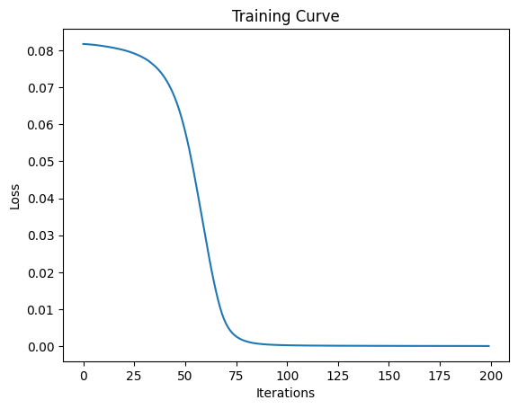

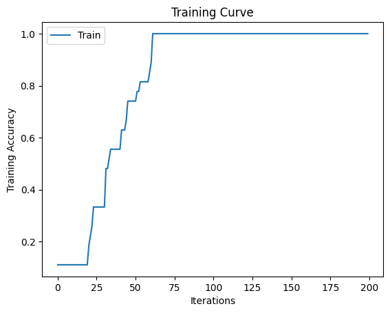

```
Final Training Accuracy: 1.0
```

```python
use_cuda = True

model = CNN()

if use_cuda and torch.cuda.is_available():
  model.cuda()
  print('CUDA is available!  Training on GPU ...')
else:
  print('CUDA is not available.  Training on CPU ...')

#proper model
train_small(model, data_small, num_epochs=200)
```

## Part 3. Hyperparameter Search

### Part (i)

List 3 hyperparameters that I think are most worth tuning. Choose at least one hyperparameter related to the model architecture.

I think batch size, number of epoch and kernel size for convolutional layer are most worth tuning.

### Part (ii)

Tune the hyperparameters I listed in Part (i). Plot the training curve of at least 4 different hyperparameter settings.

```
CUDA is available!  Training on GPU ...
<torch.utils.data.dataloader.DataLoader object at 0x7bf8dc4c7100>
```

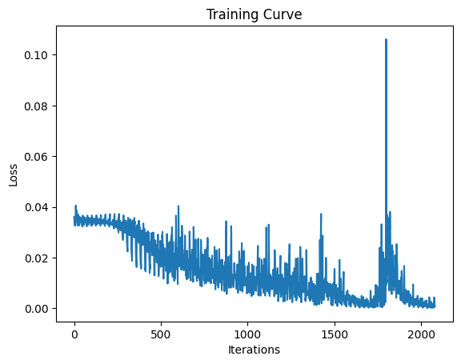

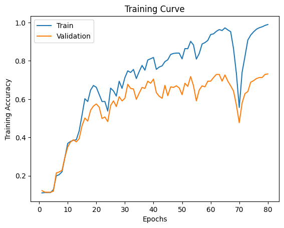

```
Final Training Accuracy: 0.9897652016857315
Final Validation Accuracy: 0.7317073170731707
```

```python
# default set 10*53*53; batch size 64; epoch 80
use_cuda = True

model_1 = CNN()

if use_cuda and torch.cuda.is_available():
  model_1.cuda()
  print('CUDA is available!  Training on GPU ...')
else:
  print('CUDA is not available.  Training on CPU ...')

#proper model
train(model_1, train_data)
```

```
CUDA is available!  Training on GPU ...
<torch.utils.data.dataloader.DataLoader object at 0x7bf8dc517c40>
```

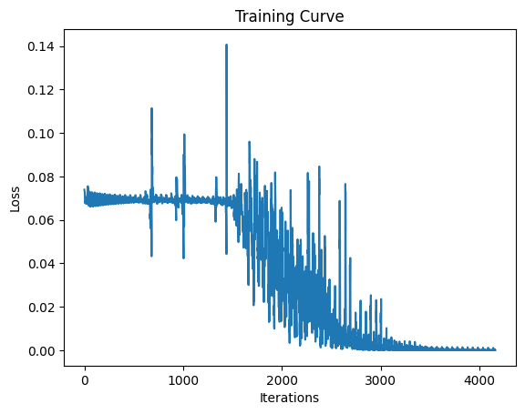

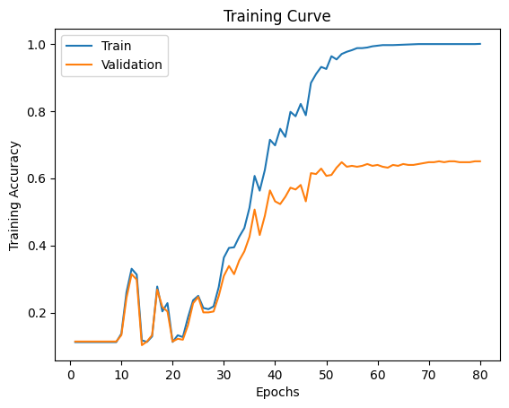

```
Final Training Accuracy: 1.0
Final Validation Accuracy: 0.6504065040650406
```

```python
# model with batch size = 32
use_cuda = True

model_2 = CNN()

if use_cuda and torch.cuda.is_available():
  model_2.cuda()
  print('CUDA is available!  Training on GPU ...')
else:
  print('CUDA is not available.  Training on CPU ...')

#proper model
train(model_2, train_data, batch_size=32)
```

```
CUDA is available!  Training on GPU ...
<torch.utils.data.dataloader.DataLoader object at 0x7bf8dc517f70>
```

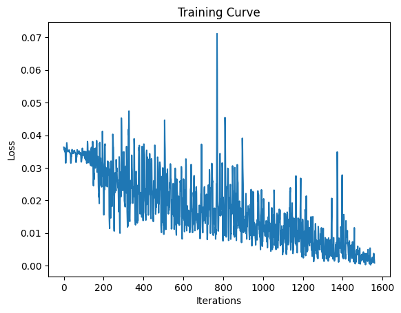

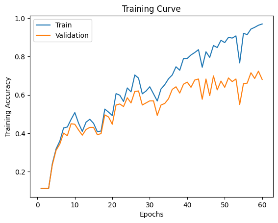

```
Final Training Accuracy: 0.9692956050571945
Final Validation Accuracy: 0.6802168021680217
```

```python
# model with number of epoch = 60
use_cuda = True

model_3 = CNN()

if use_cuda and torch.cuda.is_available():
  model_3.cuda()
  print('CUDA is available!  Training on GPU ...')
else:
  print('CUDA is not available.  Training on CPU ...')

#proper model
train(model_3, train_data, num_epochs=60)
```

```
CUDA is available!  Training on GPU ...
<torch.utils.data.dataloader.DataLoader object at 0x7c50c93e6890>
```

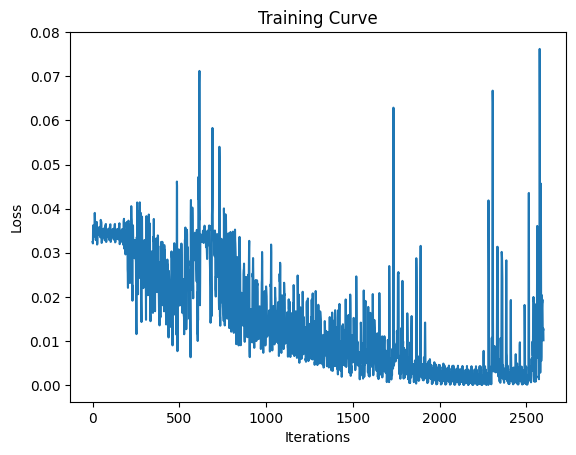

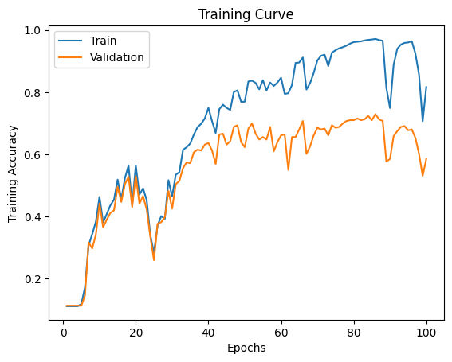

```
Final Training Accuracy: 0.8163756773028297
Final Validation Accuracy: 0.5853658536585366
```

```python
# model with number of epoch = 100
use_cuda = True

model_4 = CNN()

if use_cuda and torch.cuda.is_available():
  model_4.cuda()
  print('CUDA is available!  Training on GPU ...')
else:
  print('CUDA is not available.  Training on CPU ...')

#proper model
train(model_4, train_data, num_epochs=100)
```

```python
class CNN_new(nn.Module):
      def __init__(self):
          super(CNN_new, self).__init__()
          self.name = "cnn_new"
          self.conv1 = nn.Conv2d(3, 5, 10) #in_channels, out_chanels, kernel_size
          self.pool = nn.MaxPool2d(2, 2) #kernel_size, stride
          self.conv2 = nn.Conv2d(5, 10, 10) #in_channels, out_chanels, kernel_size
          self.fc1 = nn.Linear(10*49*49, 32)
          self.fc2 = nn.Linear(32, 9) #predict A-I

      def forward(self, x):
          x = self.pool(F.relu(self.conv1(x)))
          x = self.pool(F.relu(self.conv2(x)))
          x = x.view(-1, 10*49*49)
          x = F.relu(self.fc1(x))
          x = self.fc2(x)
          return x
```

```
CUDA is available!  Training on GPU ...
<torch.utils.data.dataloader.DataLoader object at 0x7ec56fa5d780>
```

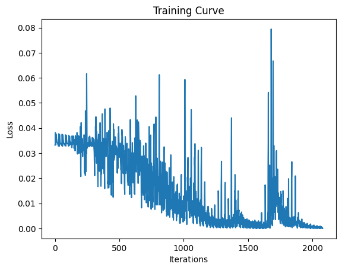

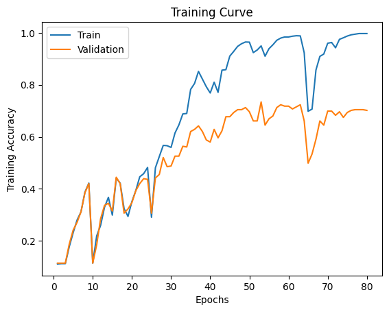

```
Final Training Accuracy: 0.9975918121613486
Final Validation Accuracy: 0.7018970189701897
```

```python
# model with kernel size =10
use_cuda = True

model_5 = CNN_new()

if use_cuda and torch.cuda.is_available():
  model_5.cuda()
  print('CUDA is available!  Training on GPU ...')
else:
  print('CUDA is not available.  Training on CPU ...')

#proper model
train(model_5, train_data)
```

### Part (iii)

Choose the best model out of all the ones that I have trained. Justify my choice.

My best model is model 1 because it has the highest validation accuracy among all models.

### Part (iv)

Report the test accuracy of my best model.

```python
def get_test_accuracy(model, batch_size=64):
    correct = 0
    total = 0
    for imgs, labels in torch.utils.data.DataLoader(test_data, batch_size):


        #############################################
        #To Enable GPU Usage
        if use_cuda and torch.cuda.is_available():
          imgs = imgs.cuda()
          labels = labels.cuda()
        #############################################


        output = model(imgs)

        #select index with maximum prediction score
        pred = output.max(1, keepdim=True)[1]
        correct += pred.eq(labels.view_as(pred)).sum().item()
        total += imgs.shape[0]
    return correct / total
```

```python
test_accuracy = get_test_accuracy(model_1, batch_size=64)
print('Test accuracy is',test_accuracy*100, '%')
```

```
Test accuracy is 57.85536159600998 %
```

Test accuracy for my best model is 57.86%

## Part 4. Transfer Learning

In this part, I will use Transfer Learning to extract features from the hand gesture images. Then, train a smaller network to use these features as input and classify the hand gestures.

Convolution layers extract various features from the images which get utilized by the fully connected layers for correct classification. AlexNet architecture played a pivotal role in establishing Deep Neural Nets as a go-to tool for image classification problems and I will use an ImageNet pre-trained AlexNet model to extract features in this assignment.

### Part (i)

Here is the code to load the AlexNet network, with pretrained weights.

```python
import torchvision.models
alexnet = torchvision.models.alexnet(pretrained=True)
```

The alexnet model is split up into two components: *alexnet.features* and *alexnet.classifier*. The first neural network component, *alexnet.features*, is used to compute convolutional features, which are taken as input in *alexnet.classifier*.

The neural network alexnet.features expects an image tensor of shape Nx3x224x224 as input and it will output a tensor of shape Nx256x6x6 . (N = batch size).

Compute the AlexNet features for each of my training, validation, and test data.

```python
classes = ['A', 'B', 'C', 'D', 'E', 'F', 'G', 'H', 'I']
```

```python
# train data
train_loader = torch.utils.data.DataLoader(train_data, batch_size=1, shuffle=True)
n = 0
for img, label in iter(train_loader):
  features = alexnet.features(img)
  features_tensor = torch.from_numpy(features.detach().numpy())
  torch.save(features_tensor.squeeze(0),'/content/gdrive/My Drive/Colab Notebooks/MIE1517/A2/train/'+ classes[label] + '/' +str(n)+'.tensor')
  n += 1
```

```python
# validation data
val_loader = torch.utils.data.DataLoader(val_data, batch_size=1, shuffle=True)
n = 0
for img, label in iter(val_loader):
  features = alexnet.features(img)
  features_tensor = torch.from_numpy(features.detach().numpy())
  torch.save(features_tensor.squeeze(0),'/content/gdrive/My Drive/Colab Notebooks/MIE1517/A2/val/'+ classes[label] + '/' +str(n)+'.tensor')
  n += 1
```

```python
# test data
test_loader = torch.utils.data.DataLoader(test_data, batch_size=1, shuffle=True)
n = 0
for img, label in iter(test_loader):
  features = alexnet.features(img)
  features_tensor = torch.from_numpy(features.detach().numpy())
  torch.save(features_tensor.squeeze(0),'/content/gdrive/My Drive/Colab Notebooks/MIE1517/A2/test/'+ classes[label] + '/' +str(n)+'.tensor')
  n += 1
```

### Part (ii)

Build a convolutional neural network model that takes as input these AlexNet features, and makes a prediction.

```python
# load features
train_features = torchvision.datasets.DatasetFolder('/content/gdrive/My Drive/Colab Notebooks/MIE1517/A2/train', loader=torch.load, extensions=('.tensor'))
val_features = torchvision.datasets.DatasetFolder('/content/gdrive/My Drive/Colab Notebooks/MIE1517/A2/val', loader=torch.load, extensions=('.tensor'))
test_features = torchvision.datasets.DatasetFolder('/content/gdrive/My Drive/Colab Notebooks/MIE1517/A2/test', loader=torch.load, extensions=('.tensor'))
```

```python
class CNN_transfer(nn.Module):
    def __init__(self):
        super(CNN_transfer, self).__init__()
        self.name = "cnn_transfer"
        self.conv1 = nn.Conv2d(256, 512, 3)
        self.pool = nn.MaxPool2d(2, 2)
        self.fc1 = nn.Linear(512 * 2 * 2, 32)
        self.fc2 = nn.Linear(32, 9)

    def forward(self, x):
        x = self.pool(F.relu(self.conv1(x)))
        x = x.view(-1, 512 * 2 * 2) #flatten feature data
        x = F.relu(self.fc1(x))
        x = self.fc2(x)
        return x
```

I chose 1 convolutional layer, 1 max-pooling layer and 2 fully-connected layers. I used the convolutional layer to help learn specific features from AlexNet, used the max pooling leayer to consolidate information and used the fully-connected layers to classify labels. I used ReLU as activation function after convolutional layers to allow nonlinearity in model. I chose kernel size = 3 for convolutional layer and kernel size = 2, stride = 2 for max pooling layer. The number of input channels for convolutional layer is 256 and number of input channels for the first fully-connected layer, I used image size(224) and calculated its shape after each convolutional and pooling layer.

### Part (iii)

Train my new network, including any hyperparameter tuning. Plot and submit the training curve of my best model only.

```python
def get_accuracy_transfer(model, train=False, batch_size=64):
    if train:
        data = train_features
    else:
        data = val_features

    correct = 0
    total = 0
    for imgs, labels in torch.utils.data.DataLoader(data, batch_size):


        #############################################
        #To Enable GPU Usage
        if use_cuda and torch.cuda.is_available():
          imgs = imgs.cuda()
          labels = labels.cuda()
        #############################################


        output = model(imgs)

        #select index with maximum prediction score
        pred = output.max(1, keepdim=True)[1]
        correct += pred.eq(labels.view_as(pred)).sum().item()
        total += imgs.shape[0]
    return correct / total
```

```python
def train_transfer(model, data, batch_size=64, num_epochs=30, learning_rate=0.001):
    train_loader = torch.utils.data.DataLoader(data, batch_size=batch_size)
    print(train_loader)
    criterion = nn.CrossEntropyLoss()
    optimizer = optim.SGD(model.parameters(), lr=learning_rate, momentum=0.95)

    iters, losses, train_acc, val_acc = [], [], [], []

    # training
    n = 0 # the number of iterations

    for epoch in range(num_epochs):
        for imgs, labels in iter(train_loader):


            #############################################
            #To Enable GPU Usage
            if use_cuda and torch.cuda.is_available():
              imgs = imgs.cuda()
              labels = labels.cuda()
            #############################################


            out = model(imgs)             # forward pass
            loss = criterion(out, labels) # compute the total loss
            loss.backward()               # backward pass (compute parameter updates)
            optimizer.step()              # make the updates for each parameter
            optimizer.zero_grad()         # a clean up step for PyTorch

            # save the current training information
            iters.append(n)
            losses.append(float(loss)/batch_size)             # compute *average* loss
            n += 1

        # save accuracy
        train_acc.append(get_accuracy_transfer(model, train=True, batch_size = batch_size)) # compute training accuracy
        val_acc.append(get_accuracy_transfer(model, train=False, batch_size = batch_size))  # compute validation accuracy

        # save model(checkpoint)
        model_path = get_model_name(model.name, batch_size, learning_rate, epoch)
        torch.save(model.state_dict(), model_path)

  # plotting
    plt.title("Training Curve")
    plt.plot(iters, losses, label="Train")
    plt.xlabel("Iterations")
    plt.ylabel("Loss")
    plt.show()

    plt.title("Training Curve")
    plt.plot(range(1, num_epochs+1), train_acc, label="Train")
    plt.plot(range(1, num_epochs+1), val_acc, label="Validation")
    plt.xlabel("Epochs")
    plt.ylabel("Training Accuracy")
    plt.legend(loc='best')
    plt.show()

    print("Final Training Accuracy: {}".format(train_acc[-1]))
    print("Final Validation Accuracy: {}".format(val_acc[-1]))
```

```
CUDA is available!  Training on GPU ...
<torch.utils.data.dataloader.DataLoader object at 0x7ec571d2d630>
```

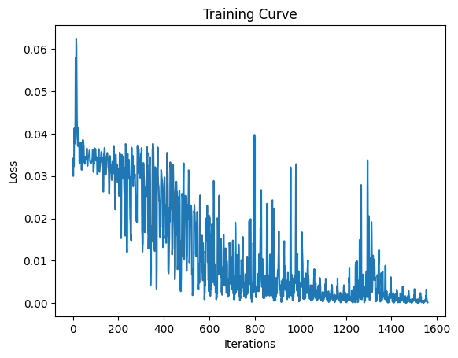

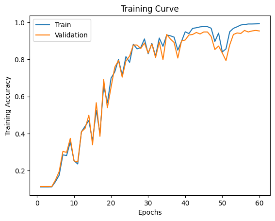

```
Final Training Accuracy: 0.9927754364840458
Final Validation Accuracy: 0.9539295392953929
```

```python
use_cuda = True

model_transfer = CNN_transfer()

if use_cuda and torch.cuda.is_available():
  model_transfer.cuda()
  print('CUDA is available!  Training on GPU ...')
else:
  print('CUDA is not available.  Training on CPU ...')

train_transfer(model_transfer, train_features, batch_size=64, num_epochs=60)
```

### Part (iv)

Report the test accuracy of my best model.

```python
def get_test_accuracy_transfer(model, batch_size=64):
    correct = 0
    total = 0
    for imgs, labels in torch.utils.data.DataLoader(test_features, batch_size):


        #############################################
        #To Enable GPU Usage
        if use_cuda and torch.cuda.is_available():
          imgs = imgs.cuda()
          labels = labels.cuda()
        #############################################


        output = model(imgs)

        #select index with maximum prediction score
        pred = output.max(1, keepdim=True)[1]
        correct += pred.eq(labels.view_as(pred)).sum().item()
        total += imgs.shape[0]
    return correct / total
```

```python
test_accuracy_trans = get_test_accuracy_transfer(model_transfer, batch_size=64)
print('Test accuracy is',test_accuracy_trans*100, '%')
```

```
Test accuracy is 76.05985037406484 %
```

The test accuracy of my best model is 76.06%, which is much higher than the test accuracy without transfer learning(57.86%).

## Part 5. Testing on New Data

As a final step in testing I will be revisiting the sample images that I had collected. These sample images should be untouched and will be used to demonstrate how well my model works at identifying my hand guestures.

### Part (i)

Load and process the hand gesture images I had collected so that they can easily be evaulated by my model.

```python
from logging import Handler
my_hand = datasets.ImageFolder('/content/gdrive/My Drive/Colab Notebooks/MIE1517/A2/Lee_1004840381', transform=transform, loader=plt.imread)

# test my hand
hand_loader = torch.utils.data.DataLoader(my_hand, batch_size=1, shuffle=True)
n = 0
for img, label in iter(hand_loader):
  features = alexnet.features(img)
  features_tensor = torch.from_numpy(features.detach().numpy())
  torch.save(features_tensor.squeeze(0),'/content/gdrive/My Drive/Colab Notebooks/MIE1517/A2/Lee_1004840381/'+ classes[label] + '/' +str(n)+'.tensor')
  n += 1
```

```python
hand_features = torchvision.datasets.DatasetFolder('/content/gdrive/My Drive/Colab Notebooks/MIE1517/A2/Lee_1004840381', loader=torch.load, extensions=('.tensor'))
```

### Part (ii)

Using the best transfer learning model developed in Part 4. Report the test accuracy on my sample images and how it compares to the test accuracy obtained in Part 4(iv).

```python
def get_test_accuracy_hands(model, batch_size=64):
    correct = 0
    total = 0
    for imgs, labels in torch.utils.data.DataLoader(hand_features, batch_size):


        #############################################
        #To Enable GPU Usage
        if use_cuda and torch.cuda.is_available():
          imgs = imgs.cuda()
          labels = labels.cuda()
        #############################################


        output = model(imgs)

        #select index with maximum prediction score
        pred = output.max(1, keepdim=True)[1]
        correct += pred.eq(labels.view_as(pred)).sum().item()
        total += imgs.shape[0]
    return correct / total
```

```python
part4_accuracy = get_test_accuracy_hands(model_transfer)
print('Test accuracy for part4 best model is',part4_accuracy*100, '%')
```

```
Test accuracy for part4 best model is 100.0 %
```

```python
def get_test_accuracy_hands_part3(model, batch_size=64):
    correct = 0
    total = 0
    for imgs, labels in torch.utils.data.DataLoader(my_hand, batch_size):


        #############################################
        #To Enable GPU Usage
        if use_cuda and torch.cuda.is_available():
          imgs = imgs.cuda()
          labels = labels.cuda()
        #############################################


        output = model(imgs)

        #select index with maximum prediction score
        pred = output.max(1, keepdim=True)[1]
        correct += pred.eq(labels.view_as(pred)).sum().item()
        total += imgs.shape[0]
    return correct / total
```

```python
part3_accuracy = get_test_accuracy_hands_part3(model_1)
print('Test accuracy for part3 best model is',part3_accuracy*100, '%')
```

```
Test accuracy for part3 best model is 44.44444444444444 %
```

```python
# present results in pandas df
import pandas as pd
data = {'model': ["Part3 best model", "Part4 best model"],
        'test accuracy for test data': [57.86, 76.06],
        'test accuracy for my sample images': [44.44, 100]}

df = pd.DataFrame(data)

df
```

|  | model | test accuracy for test data | test accuracy for my sample images |
| --- | --- | --- | --- |
| 0 | Part3 best model | 57.86 | 44.44 |
| 1 | Part4 best model | 76.06 | 100.00 |

For best model in part4, the test accuracy for my sample images is 100% while its test accuracy in part 4 is 76.05%. For best model in part3, the test accuracy for my sample images is 44.44% while its test accuracy in part 3 is 57.86%

### Part (iii)

My customed CNN perform poorly on new and unseen dataset. The training accuracy is 98.98%, validation accuracy is 73.17%, testing accuracy is 57.86% and test accuracy using my own hand gestures is only 44.44%. The training and validation accuracy are high but both testing accuracy are low. This is because my model is overfitting, memorizing all the noise in training data and fail to generalize on new data. One possible reason behind is that our dataset is too small(only 2431 images) and it contains many noise. It is hard to train a robust model with small dataset.

In contrast, my transfer learning model performs really well on differeent images. The training accuracy is 99.28%, validation accuracy is 95.39%, testing accuracy is 76.06% and test accuracy using my own hand gestures is 100%. This shows the model is successful in extracting underlying features and using them to classify. This is because AlexNet already learned something general and useful about representing images and this representation makes classification easier. Using this pretrained model, small dataset will no longer be a problem, which solve the problem occured on my customed CNN.

I think my customed CNN would perform poorly in real-world task while AlexNet model will perform very well. To improve model performance in real-world, I will perform data augmentation through scale, rotation and translation transformations. Through variation of data, my model can learn to generalize. I will also collect more data including images with messy background, which is more closed to real-world situation. In addition, I will apply regularization to model to prevent overfitting.

### Saving to HTML

```python
%%shell
jupyter nbconvert --to html /content/Hand_Gesture_Recognition.ipynb
```

[output not shown]